# 01_simulate_data

Suguru Otani

2022/12/03

# Load

linear_linear_n_50_sigma_0.001 linear_linear_n_50_sigma_0.5 linear_linear_n_50_sigma_1 linear_linear_n_50_sigma_2 linear_linear_n_100_sigma_0.001 linear_linear_n_100_sigma_0.5 linear_linear_n_100_sigma_1 linear_linear_n_100_sigma_2 linear_linear_n_200_sigma_0.001 linear_linear_n_200_sigma_0.5 linear_linear_n_200_sigma_1 linear_linear_n_200_sigma_2 linear_linear_n_1000_sigma_0.001 linear_linear_n_1000_sigma_0.5 linear_linear_n_1000_sigma_1 linear_linear_n_1000_sigma_2 linear_linear_n_2000_sigma_0.001 linear_linear_n_2000_sigma_0.5 linear_linear_n_2000_sigma_1 linear_linear_n_2000_sigma_2 loglinear_loglinear_n_50_sigma_0.001 loglinear_loglinear_n_50_sigma_0.5 loglinear_loglinear_n_50_sigma_1 loglinear_loglinear_n_50_sigma_2 loglinear_loglinear_n_100_sigma_0.001 loglinear_loglinear_n_100_sigma_0.5 loglinear_loglinear_n_100_sigma_1 loglinear_loglinear_n_100_sigma_2 loglinear_loglinear_n_200_sigma_0.001 loglinear_loglinear_n_200_sigma_0.5 loglinear_loglinear_n_200_sigma_1 loglinear_loglinear_n_200_sigma_2 loglinear_loglinear_n_1000_sigma_0.001 loglinear_loglinear_n_1000_sigma_0.5 loglinear_loglinear_n_1000_sigma_1 loglinear_loglinear_n_1000_sigma_2 loglinear_loglinear_n_2000_sigma_0.001 loglinear_loglinear_n_2000_sigma_0.5 loglinear_loglinear_n_2000_sigma_1 loglinear_loglinear_n_2000_sigma_2

# Estimation

## linear-demand linear-cost

$$\begin{align}
P_t = \alpha_0 - (\alpha_1 + \alpha_2Z^R_t)Q_t + \alpha_3 Y_t +
\varepsilon_{dt},\\
MC_t = \gamma_0 + \gamma_1 Q + \gamma_2 w_t + \gamma_3 r_t +
\varepsilon_{ct},
\end{align}$$
where $w_t$ and $r_t$ are excluded cost shifter. The supply equation is given as
$$\begin{align}
P_t = \gamma_0 + [\theta(\alpha_1 + \alpha_2Z^R_t)+ \gamma_1]
Q_t + \gamma_2 w_t + \gamma_3 r_t + \varepsilon_{ct}
\end{align}$$

From the supply equation and the demand equation, we can represent the aggregate quantity $Q_t$ based on the parameters and the exogenous variables as
$$\begin{align}
Q_t = \frac{\alpha_0 + \alpha_3 Y_t - \gamma_0 - \gamma_2 w_t -
\gamma_3 r_t + \varepsilon_{dt} - \varepsilon_{ct}}{(1 + \theta)
(\alpha_1 + \alpha_2Z^R_t) + \gamma_1}.
\end{align}$$

### n = 50

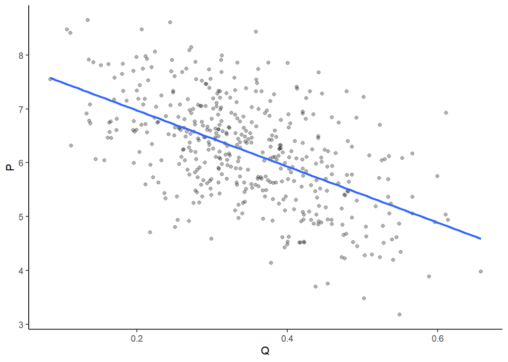

```r
generate_plot(
    linear_linear_n_50_sigma_0.001
  )
```

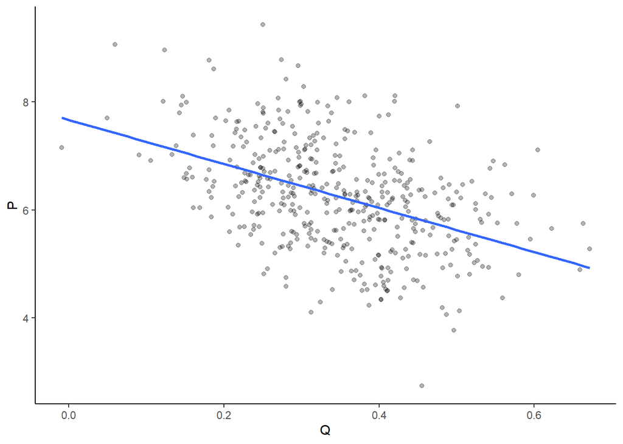

```r
generate_plot(
    linear_linear_n_50_sigma_0.5
  )
```

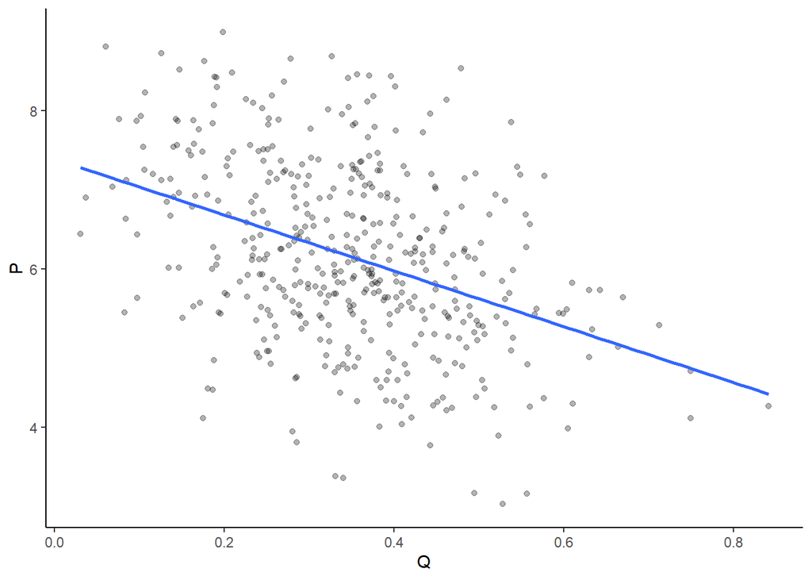

```r
generate_plot(
    linear_linear_n_50_sigma_1
  )
```

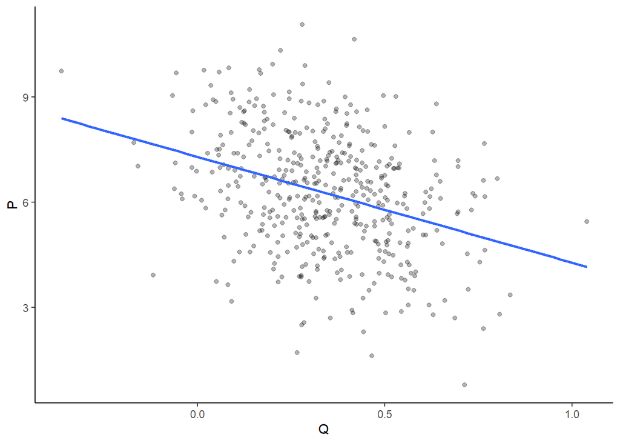

```r
generate_plot(
    linear_linear_n_50_sigma_2
  )
```

### n = 100

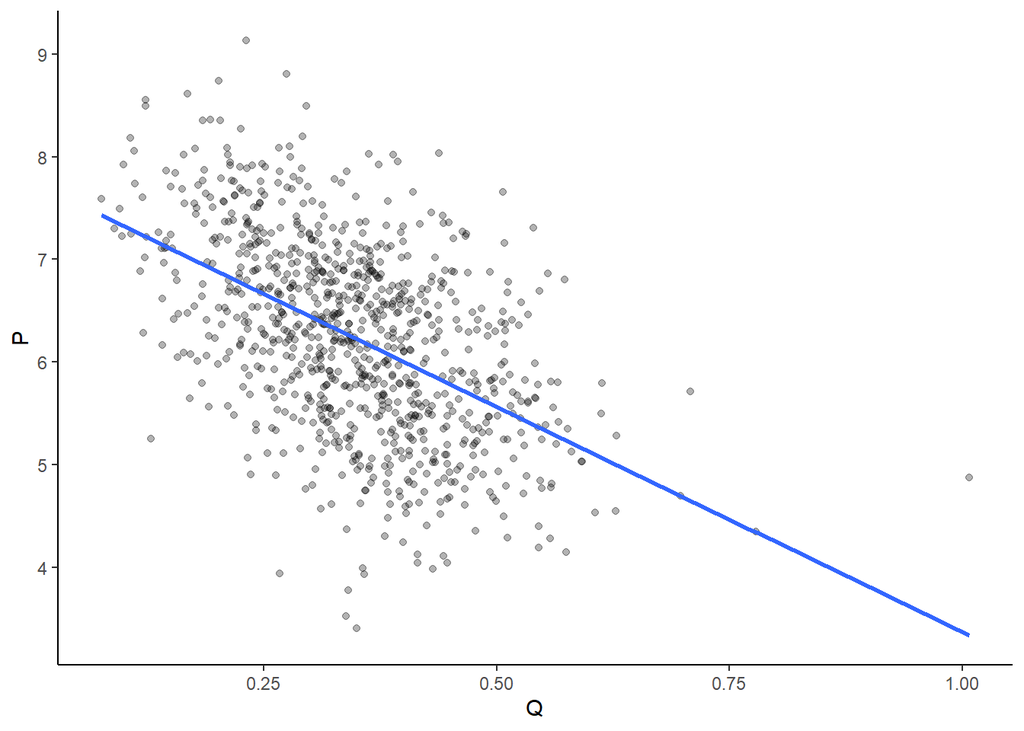

```r
generate_plot(
    linear_linear_n_100_sigma_0.001
  )
```

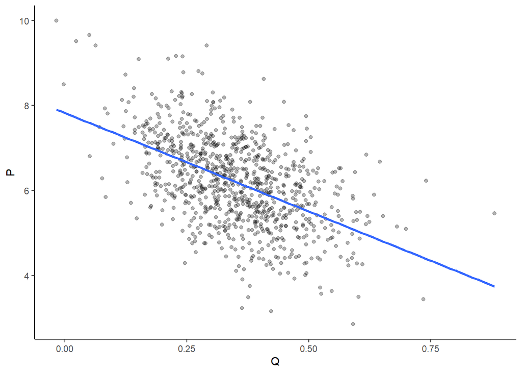

```r
generate_plot(
    linear_linear_n_100_sigma_0.5
  )
```

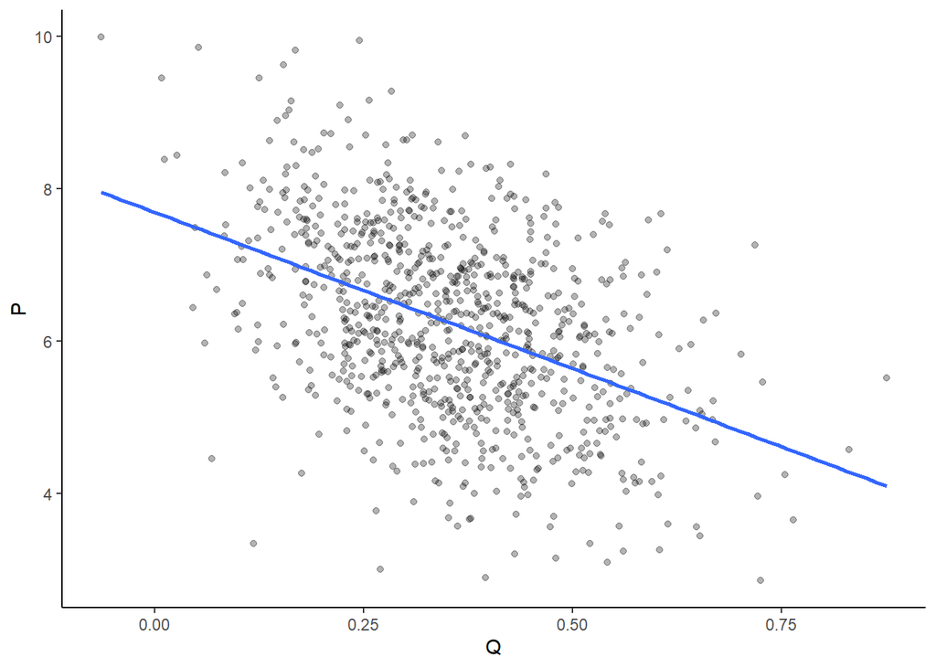

```r
generate_plot(
    linear_linear_n_100_sigma_1
  )
```

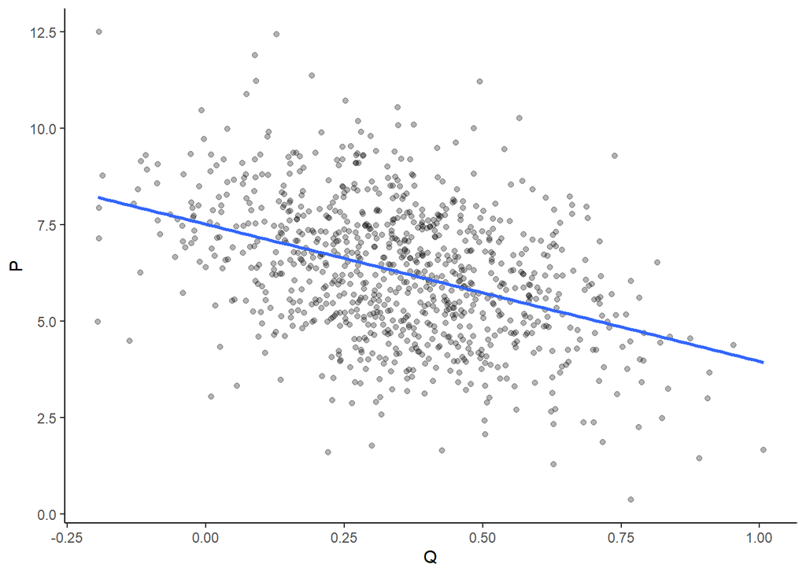

```r
generate_plot(
    linear_linear_n_100_sigma_2
  )
```

### n = 200

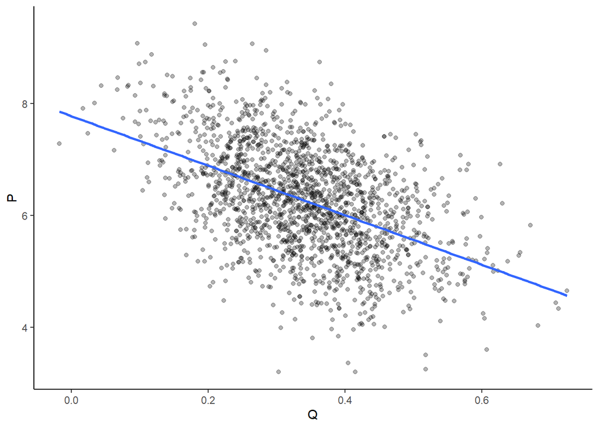

```r
generate_plot(
    linear_linear_n_200_sigma_0.001
  )
```

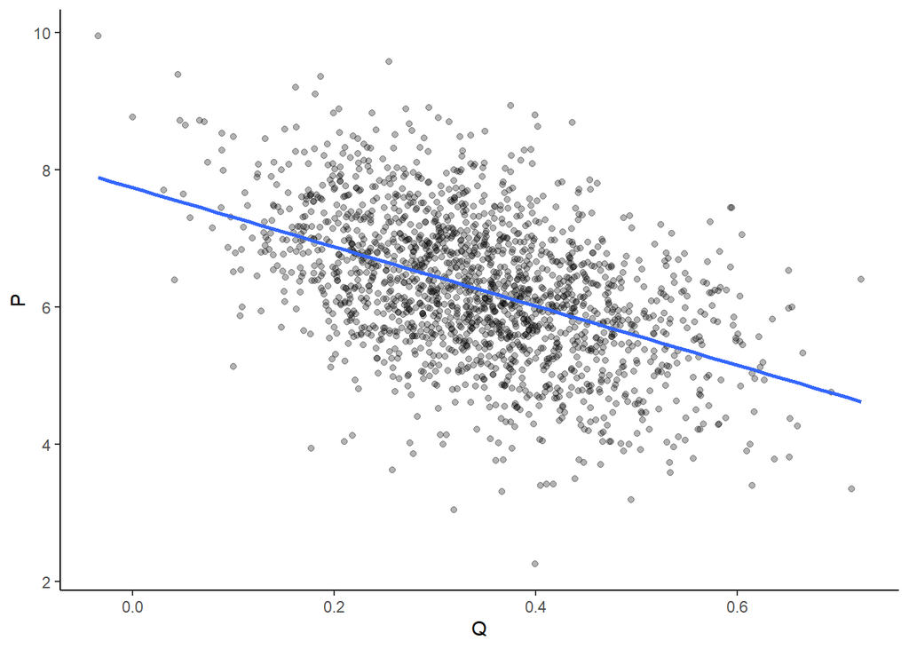

```r
generate_plot(
    linear_linear_n_200_sigma_0.5
  )
```

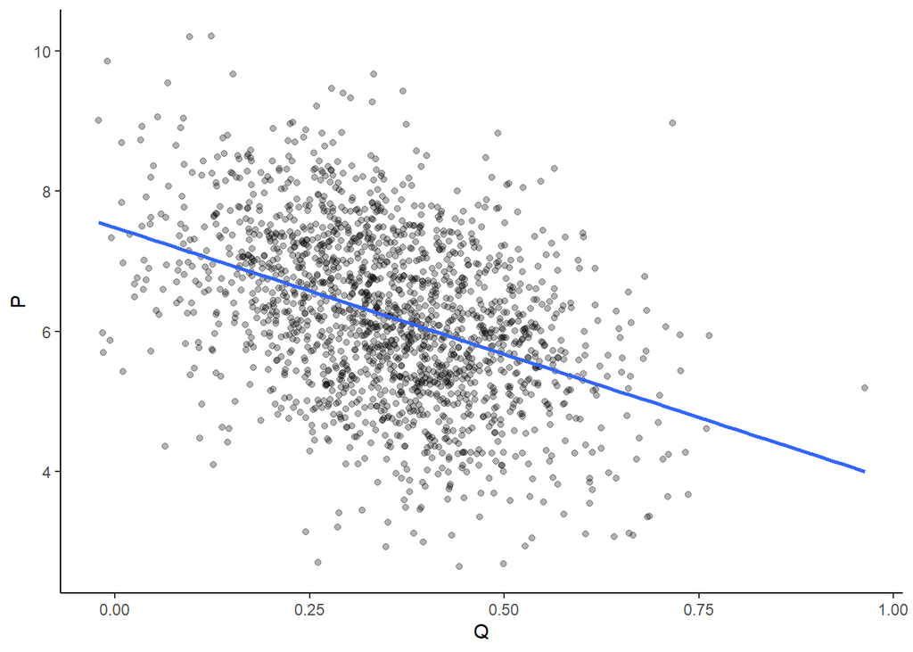

```r
generate_plot(
    linear_linear_n_200_sigma_1
  )
```

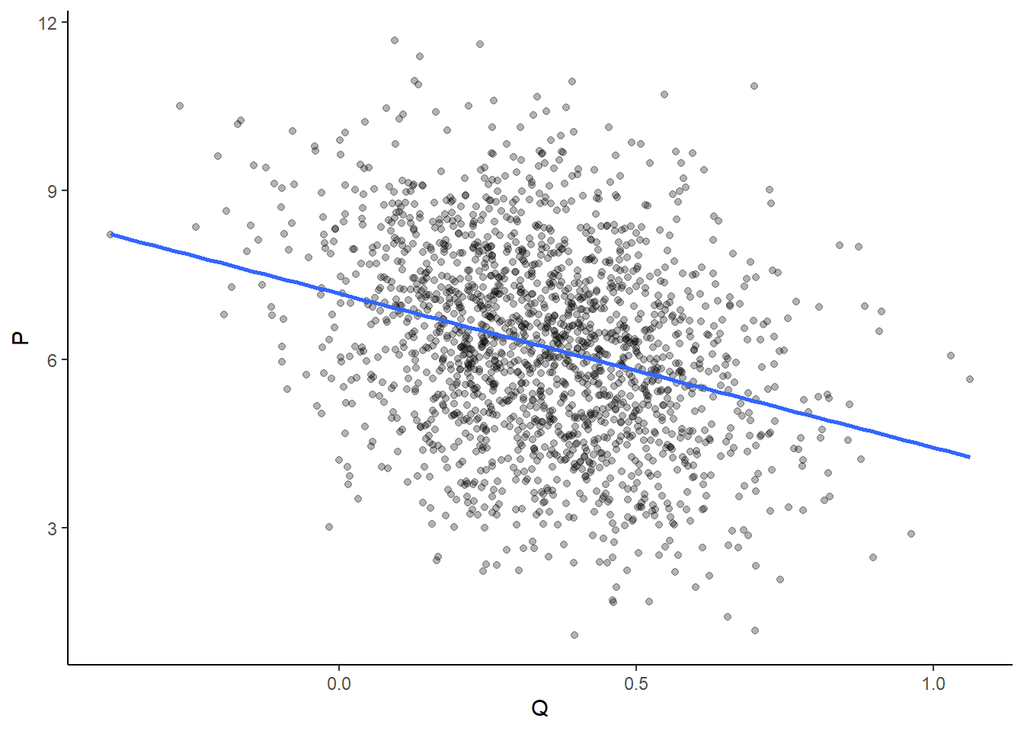

```r
generate_plot(
    linear_linear_n_200_sigma_2
  )
```

### n = 1000

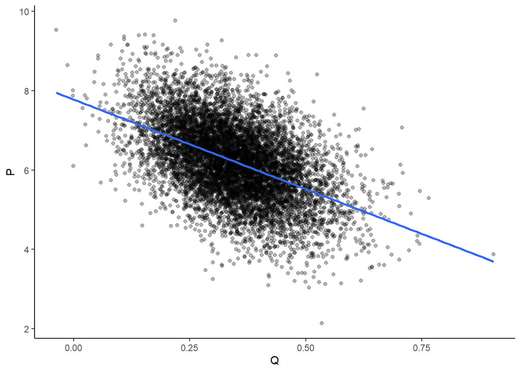

```r
generate_plot(
    linear_linear_n_1000_sigma_0.001
  )
```

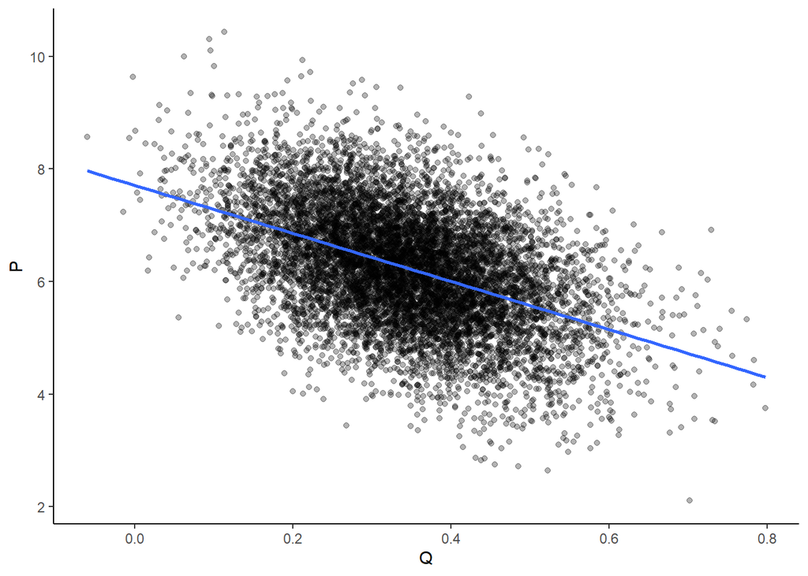

```r
generate_plot(
    linear_linear_n_1000_sigma_0.5
  )
```

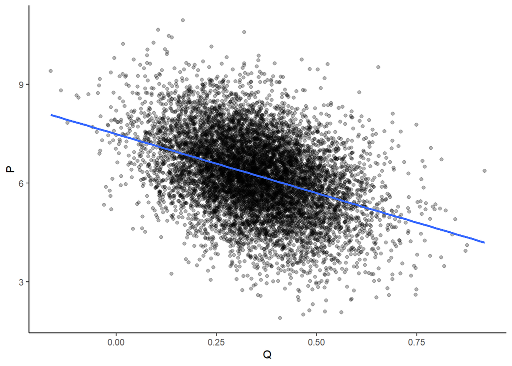

```r
generate_plot(
    linear_linear_n_1000_sigma_1
  )
```

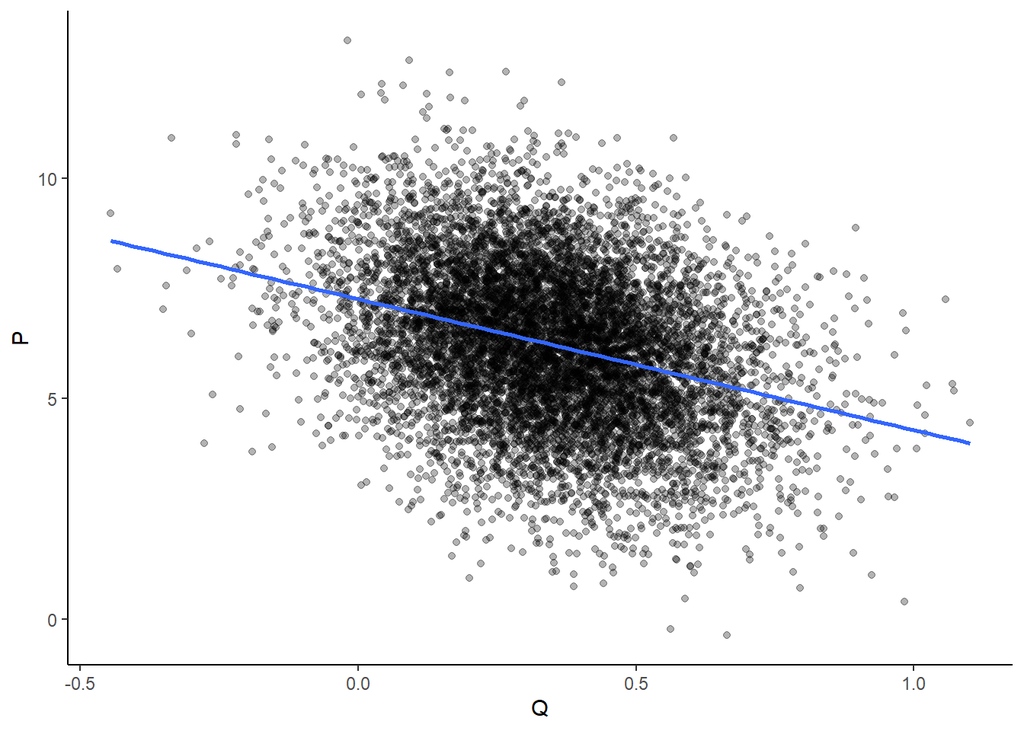

```r
generate_plot(
    linear_linear_n_1000_sigma_2
  )
```